# Final Project

Sk Nafiz Rahaman, Shakiru Oluwasanjo Oyeniran, Yingshan Qiu

2023-12-01

## Data Pre-Processing

In this section, we use the dataset which collects information on beneficiaries, including smoking status of each beneficiary, and some other personal information including age, sex, body mass index, number of children, residential area and medical costs billed by the health insurance companies. Our aim is to use these personal information to fit the model of estimating a beneficiary smoking or not.

```r
mydata <- read.csv("expenses.csv")
head(mydata)
```

```
##   age    sex    bmi children smoker    region   charges
## 1  19 female 27.900        0    yes southwest 16884.924
## 2  18   male 33.770        1     no southeast  1725.552
## 3  28   male 33.000        3     no southeast  4449.462
## 4  33   male 22.705        0     no northwest 21984.471
## 5  32   male 28.880        0     no northwest  3866.855
## 6  31 female 25.740        0     no southeast  3756.622
```

Importantly, we need to transfer our data into a numeric matrix. This step is very important! Or the function behind will not work! The format must be numeric matrix! List or data frame will not make these functions work!

```r
mydata$sex <- factor(mydata$sex,
                     levels = c("male","female"), labels = c(0,1))
mydata$smoker <- factor(mydata$smoker, levels = c("yes","no"), labels = c(1,0))
mydata$region_northeast <- ifelse(mydata$region=="northeast",1,0)
mydata$region_northwest <- ifelse(mydata$region=="northwest",1,0)
mydata$region_southeast <- ifelse(mydata$region=="southeast",1,0)
mydata <- mydata[,-6]
names <- colnames(mydata)

mydata <- as.matrix(mydata)
mydata <- as.numeric(mydata)
class(mydata)
```

```
## [1] "numeric"
```

```r
summary(mydata)
```

```
##     Min.  1st Qu.   Median     Mean  3rd Qu.     Max.
##     0.00     0.00     1.00  1482.54    29.59 63770.43
```

```r
mydata <- matrix(mydata, ncol=9)

#X: predictor variables
X <- mydata[, c(1:4,6:9)]
colnames(X) <- names[c(1:4,6:9)]

#Y: response variable (smoke or not)
Y <- mydata[, 5]
```

## Logistic Regression

The formula of losgistic regression based on response variable y and predictor variables $X_1$, $X_2$, … $X_k$ is

$$\hat{y} =
\frac{1}{1+e^{-(\beta_0+\beta_1x_1+\cdots+\beta_kx_k)}}=\frac{1}{1+e^{-x^T\beta}}$$
The best estimator of the coefficient vector $\beta$ is computed with the least value of loss function of logistic regression, and the numerical optimization process is shown in the following:

$$\hat{\beta}=\mathop{\arg\min}\limits_{\beta}\sum_{i=1}^n (-y_i\cdot
\text{ln}(p_i)-(1-y_i)\cdot \text{ln}(1-p_i))$$
where
$$pi=\frac{1}{1+\text{exp}(-x_i^T\beta)},$$
and $y_i$ and $x_i$ represent the ith observation and row of the response and the predictors respectively.

#### Initial values for optimization

In order to start an optimization process, we need to define a initial value of coefficient matrix. In order to get the estimator more accurately, we use the least-square estimator as the initial matrix of coefficient.Now we create a function `init` which can get our initial values of beta:

```r
init <- function(resp, pred){
  a <- nrow(pred)
  c <- rep(1, nrow(pred))
  x_mat <- as.matrix(cbind(c, pred))
  beta_vec <- solve(t(x_mat)
                    %*%(x_mat))%*%t(x_mat)%*%resp
  return(beta_vec)
}
```

```r
init_beta_demo <- init(resp = Y, pred= X)
```

Then, we need construct a function of loss value. The function name would be `loss_value`:

```r
loss_value <- function(pred, resp, beta){
  a <- nrow(pred)
  c <- rep(1,a)
  x_mat <- cbind(c, pred)
  d <- rep(0,a)
  for(i in 1:a){
    d[i] <- x_mat[i,]%*%beta
  }
  loss <- rep(0,a)
  for(i in 1:a){
    loss[i] <- ((-resp[i])*log(1/(1+exp(-d[i])))-(1-resp[i])*log(exp(-d[i])/(1+exp(-d[i]))))
  }
  return(sum(loss))
}
```

```r
loss_value_demo <- loss_value(pred= X,resp= Y, beta=init_beta_demo)
```

Now,we create a function to get a demo estimate for the optimal beta. The function name would be `optim_beta`:

```r
optim_beta <- function(init_coef, pred, resp){
  par <- optim(init_coef,
               fn=loss_value,
               pred= X,
               resp= Y)$par
  return(par)
}
```

```r
optim_beta_demo <- optim_beta(init_coef=init_beta_demo, pred= X, resp= Y)
```

#### Bootstrap Confidence intervals

Now we create a function that get the Bootstrap Confidence intervals of beta. The default value of n is 20, which is the number of Bootstraps. The default value of alpha is 0.05, which is the value of significance level. The function name would be `Boot_CI`:

```r
Boot_CI <- function(n=20, alpha=0.05, pred, resp){
  whole <- cbind(pred, resp)
  a <- nrow(pred)
  c <- ncol(pred)+1
  b <- matrix(0, nrow=n, ncol=c)
  for (i in 1:n){
    whole_star <- whole[sample(1:a, replace = TRUE),]
    init_beta <- init(resp = whole[,c],
                      pred= whole[, -c])
    b[i,] <- optim(init_beta, fn=loss_value,
                   pred=whole_star[, -c],
                   resp=whole_star[,c])$par
  }
  final <- matrix(0, nrow = c, ncol=2)
  for(i in 1:c){
    final[i,] <- quantile(b[,i], c(alpha/2, 1 - alpha/2))
  }
  return(final)
}
```

```r
Boot_CI_demo <- Boot_CI(n=20, alpha=0.05, pred= X, resp= Y)
```

#### Drawing a fitted plot of logistic regression

We would create a function which would draw the fitted logistic curve to the responses. The y-axis is the binary response y. The x-axis represents a sequence of values from the range of fitted value $\hat{y}= x^T \beta$. The function name is `log_plot`.

```r
log_plot <- function(pred, resp){
  b <- rep(0, nrow(pred))
  whole <- cbind(pred, resp, b)
  c <- ncol(whole)
  # get the start value of beta

  h <- rep(1, nrow(pred))
  x_mat <- cbind(c, pred)
  init_beta <- solve(t(x_mat)
                     %*%(x_mat))%*%t(x_mat)%*%resp

  optim_beta_demo <- optim(init_beta,
                           fn=loss_value,
                           pred=whole[,c(1:(c-2))],
                           resp=whole[,(c-1)])$par

  whole[,c] <- x_mat %*% optim_beta_demo
  whole <- whole[order(whole[,c]),]
  plot(whole[,(c-1)] ~ whole[,c])
  aaa <- cbind(whole[,c] , whole[,(c-1)])
  aaa <- as.data.frame(aaa)
  plot(aaa[,2]~aaa[,1], xlab="X%*%Beta"
       , ylab="binary response y")
  logistic_model <- glm(aaa[,2]~aaa[,1], data=aaa,
                        family=binomial)
  Predicted_data <- data.frame(var2=seq(
    min(aaa[,1]), max(aaa[,1]),len=nrow(pred)))
  Predicted_data$var1 = predict(
    logistic_model, Predicted_data, type="response")
  lines(var1 ~ var2, Predicted_data, lwd=2, col="green")
}
```

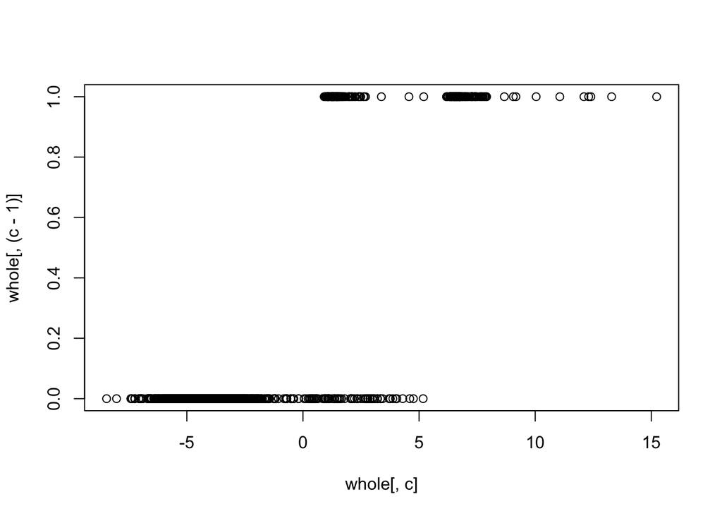

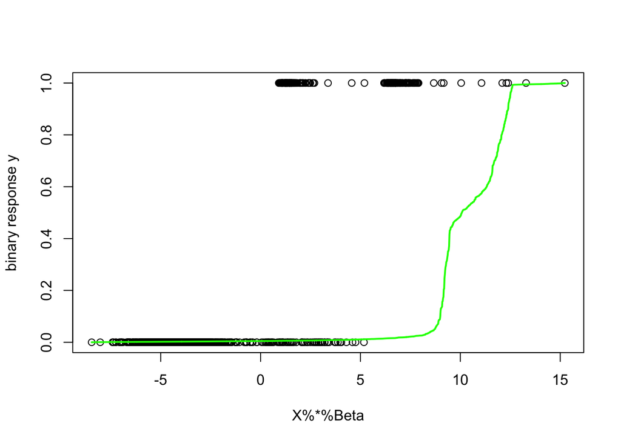

```r
# Example
log_plot(pred= X, resp= Y)
```

Therefore, we get a plot of fitted logistic curve to the response.

## Confusion Matrix

Confusion matrix is a specific table layout that allows visualization of the performance of an algorithm. Each row of the matrix represents the instances in an actual class while each column represents the instances in a predicted class.

The template for any binary confusion matrix uses the four kinds of results (true positives, false negatives, false positives, and true negatives) along with the positive and negative classifications. The four outcomes can be formulated in a confusion matrix, as follows:

| Total | Predicted Positive (PP) | Predicted Negative (PN) |
| --- | --- | --- |
| Actual Positive (P) | True Positive (TP) | False Negative (FN) |
| Actual Negative (N) | False Positive (FP) | True Negative (TN) |

Based on the confusion matrix, we can compute the following metrics:
$$\begin{align}
&\text{Prevalence}=\frac{\text{P}}{\text{P}+\text{N}}\\
&\text{Accuracy
(ACC)}=\frac{\text{TP}+\text{TN}}{\text{P}+\text{N}}=\frac{\text{TP}+\text{TN}}{\text{TP}+\text{TN}+\text{FP}+\text{FN}}\\
&\text{Sensitivity
(TPR)}=\frac{\text{TP}}{\text{P}}=\frac{\text{TP}}{\text{TP}+\text{FN}}\\
&\text{Specificity
(TNR)}=\frac{\text{TN}}{\text{N}}=\frac{\text{TN}}{\text{TN}+\text{FP}}\\
&\text{False Discovery Rate
(FDR)}=\frac{\text{FP}}{\text{FP}+\text{TP}}\\
&\text{Diagnostic Odds Ratio
(DOR)}=\frac{\text{LR}_+}{\text{LR}_-}=\frac{\text{TPR}/\text{FPR}}{\text{FNR}/\text{TNR}}
\end{align}$$

#### Generating the confusion matrix of logistic regression

The function name is `conf_mat`.

```r
conf_mat <- function(pred, resp){
  b <- rep(0, nrow(pred))
  whole <- cbind(pred, resp, b)
  c <- ncol(whole)
  # get the start value of beta

  h <- rep(1, nrow(pred))
  x_mat <- cbind(c, pred)
  init_beta <- solve(t(x_mat)
                     %*%(x_mat))%*%t(x_mat)%*%resp

  optim_beta_demo <- optim(init_beta,
                           fn=loss_value, pred=whole[,c(1:(c-2))], resp=whole[,(c-1)])$par

  whole[,c] <- (1+exp(-x_mat %*% optim_beta_demo))^(-1)
  whole <- whole[order(whole[,c]),]
  aaa <- cbind(whole[,c] , whole[,(c-1)])

  #Create the confusion matrix
  confusion <- matrix(rep(0,9),3,3)
  for(i in 1:nrow(pred)){
    if(aaa[i,1] >= 0.5 & aaa[i,2]==1){
      confusion[2,2] <- confusion[2,2]+1
    }else if(aaa[i,1] < 0.5 & aaa[i,2]==1){
      confusion[2,3] <- confusion[2,3]+1
    }else if(aaa[i,1] > 0.5 & aaa[i,2]==0){
      confusion[3,2] <- confusion[3,2]+1
    }else{
      confusion[3,3] <- confusion[3,3]+1
    }
  }
  confusion[1,1] <- (confusion[2,2]+confusion[2,3]
                     +confusion[3,2]+confusion[3,3])
  confusion[1,2] <- (confusion[2,2]+confusion[3,2])
  confusion[1,3] <- (confusion[2,3]+confusion[3,3])
  confusion[2,1] <- (confusion[2,2]+confusion[2,3])
  confusion[3,1] <- (confusion[3,2]+confusion[3,3])

  colnames(confusion) <- c("Total","Predicted Yes","Predicted Yes")
  rownames(confusion) <- c("Total","Actual Yes","Actual Yes")

  #Print such metrics
  Prevalence <- confusion[2,1]/confusion[1,1]
  cat(sprintf("The Prevalence is %f\n", Prevalence))
  Accuracy <- (confusion[2,2]+confusion[3,3])/confusion[1,1]
  cat(sprintf("The Accuracy is %f\n", Accuracy))
  Sensitivity <- confusion[2,2]/confusion[2,1]
  cat(sprintf("The Sensitivity is %f\n", Sensitivity))
  Specificity <- confusion[3,3]/confusion[3,1]
  cat(sprintf("The Specificity is %f\n", Specificity))
  False_Discovery_Rate <- confusion[3,2]/(confusion[3,2]+confusion[2,2])
  cat(sprintf("The False Discovery Rate is %f\n", False_Discovery_Rate))
  LR_plus <- (confusion[2,2]/confusion[2,1])/(confusion[3,2]/confusion[3,1])
  LR_minus <- (confusion[2,3]/confusion[2,1])/(confusion[3,3]/confusion[3,1])
  Diagnostic_Odds_Ratio <- LR_plus/LR_minus
  cat(sprintf("The Diagnostic Odds Ratio is %f\n", Diagnostic_Odds_Ratio))

  return(confusion)
}
```

```r
# Example
confusion_matrix_demo <- conf_mat(pred=X, resp=Y)
```

```
## The Prevalence is 0.204783
## The Accuracy is 0.949925
## The Sensitivity is 1.000000
## The Specificity is 0.937030
## The False Discovery Rate is 0.196481
## The Diagnostic Odds Ratio is Inf
```

```r
# Confusion Matrix
confusion_matrix_demo
```

```
##            Total Predicted Yes Predicted Yes
## Total       1338           341           997
## Actual Yes   274           274             0
## Actual Yes  1064            67           997
```

As we see, the confusion matrix is a 3*3 matrix, and we also out put the metrics of Prevalence, Accuracy, Sensitivity, Specificity, False Discovery Rate and Diagnostic Odds Ratio.

#### Plots of any of metrics based on different cut-off values from 0.1 to 0.9 with steps of 0.1

In order to solve this problem, we need to calculate all the 9 situations with the different cut-off values. This would be a comprehensive work. We need an array to store our 9 confusion matrix and print all the metrics in all the situations of different cut-off values. The function name is `compre_cal`.

Firstly, we could create a new function where users could select cut-off values freely, The function name is `conf_mat_free`, compared to the function `conf_mat`.

```r
conf_mat_free <- function(pred, resp, value){
  b <- rep(0, nrow(pred))
  whole <- cbind(pred, resp, b)
  c <- ncol(whole)
  # get the start value of beta

  h <- rep(1, nrow(pred))
  x_mat <- cbind(c, pred)
  init_beta <- solve(t(x_mat)
                     %*%(x_mat))%*%t(x_mat)%*%resp

  optim_beta_demo <- optim(init_beta,
                           fn=loss_value, pred=whole[,c(1:(c-2))], resp=whole[,(c-1)])$par

  whole[,c] <- (1+exp(-x_mat %*% optim_beta_demo))^(-1)
  whole <- whole[order(whole[,c]),]
  aaa <- cbind(whole[,c] , whole[,(c-1)])

  #Create the confusion matrix
  confusion <- matrix(rep(0,9),3,3)
  for(i in 1:nrow(pred)){
    if(aaa[i,1] >= value & aaa[i,2]==1){
      confusion[2,2] <- confusion[2,2]+1
    }else if(aaa[i,1] < value & aaa[i,2]==1){
      confusion[2,3] <- confusion[2,3]+1
    }else if(aaa[i,1] > value & aaa[i,2]==0){
      confusion[3,2] <- confusion[3,2]+1
    }else{
      confusion[3,3] <- confusion[3,3]+1
    }
  }
  confusion[1,1] <- (confusion[2,2]+confusion[2,3]
                     +confusion[3,2]+confusion[3,3])
  confusion[1,2] <- (confusion[2,2]+confusion[3,2])
  confusion[1,3] <- (confusion[2,3]+confusion[3,3])
  confusion[2,1] <- (confusion[2,2]+confusion[2,3])
  confusion[3,1] <- (confusion[3,2]+confusion[3,3])

  colnames(confusion) <- c("Total","Predicted Yes","Predicted Yes")
  rownames(confusion) <- c("Total","Actual Yes","Actual Yes")

  #Print such metrics
  cat(sprintf("When cut-off value is %f:\n", value))
  Prevalence <- confusion[2,1]/confusion[1,1]
  cat(sprintf("The Prevalence is %f\n", Prevalence))
  Accuracy <- (confusion[2,2]+confusion[3,3])/confusion[1,1]
  cat(sprintf("The Accuracy is %f\n", Accuracy))
  Sensitivity <- confusion[2,2]/confusion[2,1]
  cat(sprintf("The Sensitivity is %f\n", Sensitivity))
  Specificity <- confusion[3,3]/confusion[3,1]
  cat(sprintf("The Specificity is %f\n", Specificity))
  False_Discovery_Rate <- confusion[3,2]/(confusion[3,2]+confusion[2,2])
  cat(sprintf("The False Discovery Rate is %f\n", False_Discovery_Rate))
  LR_plus <- (confusion[2,2]/confusion[2,1])/(confusion[3,2]/confusion[3,1])
  LR_minus <- (confusion[2,3]/confusion[2,1])/(confusion[3,3]/confusion[3,1])
  Diagnostic_Odds_Ratio <- LR_plus/LR_minus
  cat(sprintf("The Diagnostic Odds Ratio is %f\n", Diagnostic_Odds_Ratio))

  return(confusion)
}
```

```r
# Example
confusion_matrix_demo2 <- conf_mat_free(pred=X, resp=Y, value = 0.8)
```

```
## When cut-off value is 0.800000:
## The Prevalence is 0.204783
## The Accuracy is 0.928251
## The Sensitivity is 0.791971
## The Specificity is 0.963346
## The False Discovery Rate is 0.152344
## The Diagnostic Odds Ratio is 100.056230
```

```r
confusion_matrix_demo2
```

```
##            Total Predicted Yes Predicted Yes
## Total       1338           256          1082
## Actual Yes   274           217            57
## Actual Yes  1064            39          1025
```

As we can see, we see when cut-off value is 0.8, we get a matrix of confusion_matrix_demo2 which is a 3*3 matrix and print all the metrics when cut-off value is 0.8.

This function is same as `conf_mat_free` function but does not print out anything.

```r
conf_mat_new <- function(pred, resp, value){
  b <- rep(0, nrow(pred))
  whole <- cbind(pred, resp, b)
  c <- ncol(whole)
  # get the start value of beta

  h <- rep(1, nrow(pred))
  x_mat <- cbind(c, pred)
  init_beta <- solve(t(x_mat)
                     %*%(x_mat))%*%t(x_mat)%*%resp

  optim_beta_demo <- optim(init_beta,
                           fn=loss_value, pred=whole[,c(1:(c-2))], resp=whole[,(c-1)])$par

  whole[,c] <- (1+exp(-x_mat %*% optim_beta_demo))^(-1)
  whole <- whole[order(whole[,c]),]
  aaa <- cbind(whole[,c] , whole[,(c-1)])

  #Create the confusion matrix
  confusion <- matrix(rep(0,9),3,3)
  for(i in 1:nrow(pred)){
    if(aaa[i,1] >= value & aaa[i,2]==1){
      confusion[2,2] <- confusion[2,2]+1
    }else if(aaa[i,1] < value & aaa[i,2]==1){
      confusion[2,3] <- confusion[2,3]+1
    }else if(aaa[i,1] > value & aaa[i,2]==0){
      confusion[3,2] <- confusion[3,2]+1
    }else{
      confusion[3,3] <- confusion[3,3]+1
    }
  }
  confusion[1,1] <- (confusion[2,2]+confusion[2,3]
                     +confusion[3,2]+confusion[3,3])
  confusion[1,2] <- (confusion[2,2]+confusion[3,2])
  confusion[1,3] <- (confusion[2,3]+confusion[3,3])
  confusion[2,1] <- (confusion[2,2]+confusion[2,3])
  confusion[3,1] <- (confusion[3,2]+confusion[3,3])
  colnames(confusion) <- c("Total","Predicted Yes","Predicted Yes")
  rownames(confusion) <- c("Total","Actual Yes","Actual Yes")
  return(confusion)
}
```

Then, we could build a comprehensive one, it would save all the data into an array, and print out all the metrics in different situations. The function name is `compre_cal`.

```r
compre_cal <- function(pred, resp){
  my_array <- array(NA, dim = c(3, 3, 9))
  for(i in 1:9){
    v <- (0.1)*i
    my_array[,,i] <- conf_mat_free(pred, resp, value = v)
  }
  return(my_array)
}
```

```r
# Example
array_demo <- compre_cal(pred=X, resp=Y)
```

```
## When cut-off value is 0.100000:
## The Prevalence is 0.204783
## The Accuracy is 0.914798
## The Sensitivity is 1.000000
## The Specificity is 0.892857
## The False Discovery Rate is 0.293814
## The Diagnostic Odds Ratio is Inf
## When cut-off value is 0.200000:
## The Prevalence is 0.204783
## The Accuracy is 0.937220
## The Sensitivity is 1.000000
## The Specificity is 0.921053
## The False Discovery Rate is 0.234637
## The Diagnostic Odds Ratio is Inf
## When cut-off value is 0.300000:
## The Prevalence is 0.204783
## The Accuracy is 0.941704
## The Sensitivity is 1.000000
## The Specificity is 0.926692
## The False Discovery Rate is 0.221591
## The Diagnostic Odds Ratio is Inf
## When cut-off value is 0.400000:
## The Prevalence is 0.204783
## The Accuracy is 0.947683
## The Sensitivity is 1.000000
## The Specificity is 0.934211
## The False Discovery Rate is 0.203488
## The Diagnostic Odds Ratio is Inf
## When cut-off value is 0.500000:
## The Prevalence is 0.204783
## The Accuracy is 0.949925
## The Sensitivity is 1.000000
## The Specificity is 0.937030
## The False Discovery Rate is 0.196481
## The Diagnostic Odds Ratio is Inf
## When cut-off value is 0.600000:
## The Prevalence is 0.204783
## The Accuracy is 0.955904
## The Sensitivity is 1.000000
## The Specificity is 0.944549
```

[output cut: 8 more lines]

```
## The Diagnostic Odds Ratio is Inf
## When cut-off value is 0.800000:
## The Prevalence is 0.204783
## The Accuracy is 0.928251
## The Sensitivity is 0.791971
## The Specificity is 0.963346
## The False Discovery Rate is 0.152344
## The Diagnostic Odds Ratio is 100.056230
## When cut-off value is 0.900000:
## The Prevalence is 0.204783
## The Accuracy is 0.895366
## The Sensitivity is 0.594891
## The Specificity is 0.972744
## The False Discovery Rate is 0.151042
## The Diagnostic Odds Ratio is 52.409133
```

Finally, we get an array of 3*3*9 dimension which stores all the confusion matrix in different situations. And we also print all the metrics in different situations. It is a comprehensive calculation.

```r
compre_cal_new <- function(pred, resp){
  my_array <- array(NA, dim = c(3, 3, 9))
  for(i in 1:9){
    v <- (0.1)*i
    my_array[,,i] <- conf_mat_new(pred, resp, value = v)
  }
  return(my_array)
}
```

```r
plot_metric <- function(resp, pred, metric){
  data_array <- compre_cal_new(pred, resp)
  if(metric == "Prevalence"){
    prevalence <- rep(0, 9)
    step <- seq(0.1, 0.9, by = 0.1)
    for(i in 1:9){
      prevalence[i] <- (data_array[2,1,i]/data_array[1,1,i])
    }
    plot(prevalence~step, xlab="cut-off value"
         , ylab="", main="Prevalence")
  }
  if(metric == "Accuracy"){
    Accuracy <- rep(0, 9)
    step <- seq(0.1, 0.9, by = 0.1)
    for(i in 1:9){
      Accuracy[i] <- ((data_array[2,2,i]+data_array[3,3,i])/data_array[1,1,i])
    }
    plot(Accuracy~step, xlab="cut-off value"
         , ylab="", main="Accuracy")
  }
  if(metric == "Sensitivity"){
    Sensitivity <- rep(0, 9)
    step <- seq(0.1, 0.9, by = 0.1)
    for(i in 1:9){
      Sensitivity[i] <- (data_array[2,2,i]/data_array[2,1,i])
    }
    plot(Sensitivity~step, xlab="cut-off value"
         , ylab="", main="Sensitivity")
  }
  if(metric == "Specificity"){
    Specificity <- rep(0, 9)
    step <- seq(0.1, 0.9, by = 0.1)
    for(i in 1:9){
      Specificity[i] <- (data_array[3,3,i]/data_array[3,1,i])
    }
    plot(Specificity~step, xlab="cut-off value"
         , ylab="", main="Specificity")
  }
  if(metric == "The False Discovery Rate"){
    The_False_Discovery_Rate <- rep(0, 9)
    step <- seq(0.1, 0.9, by = 0.1)
    for(i in 1:9){
      The_False_Discovery_Rate[i] <- (data_array[3,2,i]/(data_array[3,2,i]+data_array[2,2,i]))
    }
    plot(The_False_Discovery_Rate~step, xlab="cut-off value"
         , ylab="", main="The False Discovery Rate")
  }
  if(metric == "The Diagnostic Odds Ratio"){
    The_Diagnostic_Odds_Ratio <- rep(0, 9)
    step <- seq(0.1, 0.9, by = 0.1)
    vec_1 <- rep(0,9)
    vec_2 <- rep(0,9)
    for(i in 1:9){
      vec_1[i] <- (data_array[2,2,i]/data_array[2,1,i])/(data_array[3,2,i]/data_array[3,1,i])
      vec_2[i] <- (data_array[2,3,i]/data_array[2,1,i])/(data_array[3,3,i]/data_array[3,1,i])
      The_Diagnostic_Odds_Ratio[i] <- (vec_1[i]/vec_2[i])
    }
    plot(The_Diagnostic_Odds_Ratio~step, xlab="cut-off value"
         , ylab="", main="The Diagnostic Odds Ratio")
  }
}
```

Now we can draw the plots.

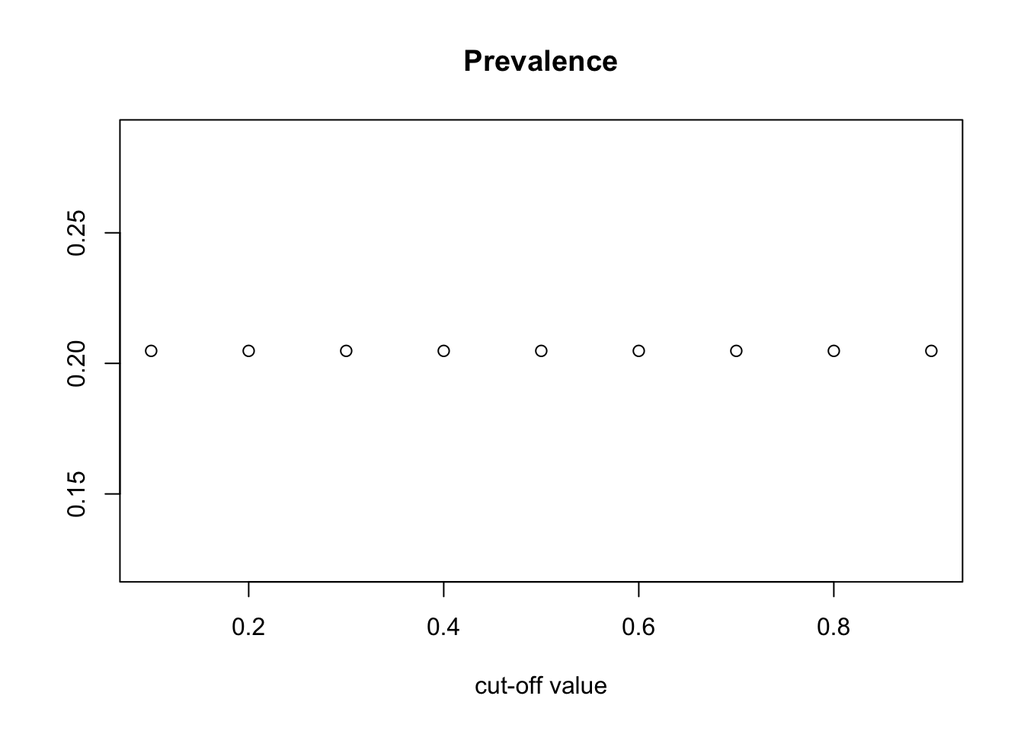

```r
plot_metric(resp=Y, pred=X, metric = "Prevalence")
```

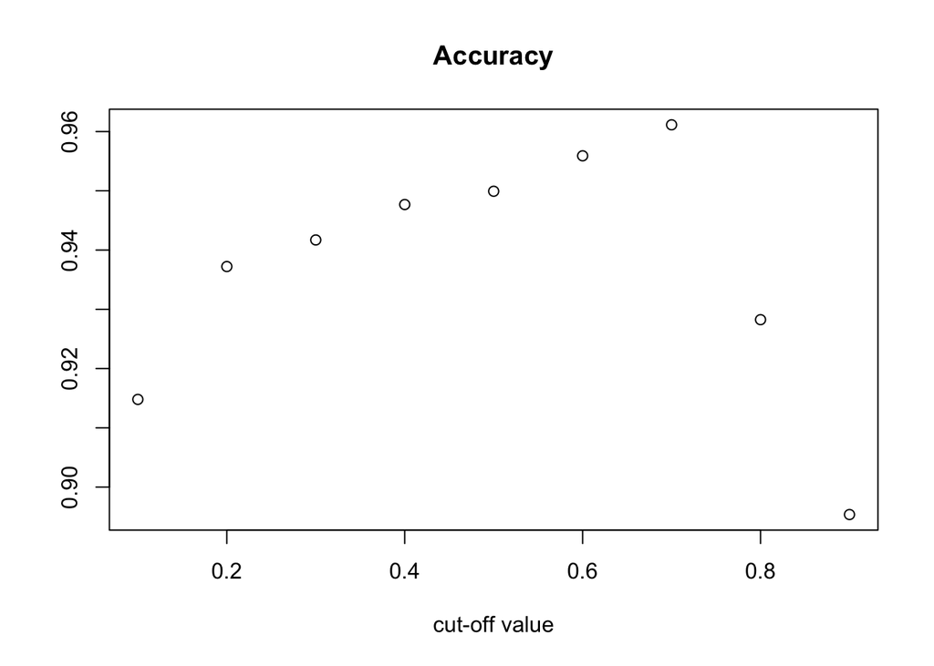

```r
plot_metric(resp=Y, pred=X, metric = "Accuracy")
```

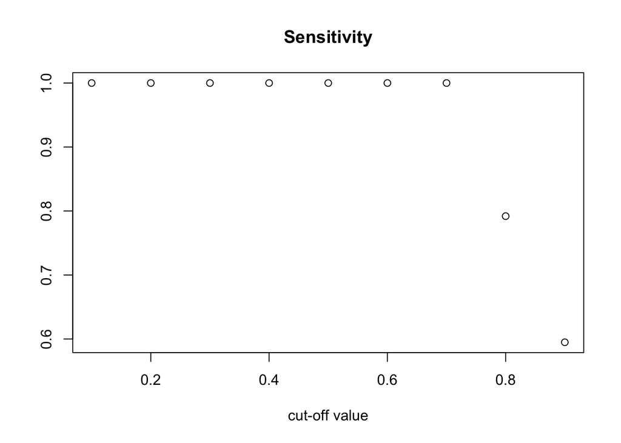

```r
plot_metric(resp=Y, pred=X, metric = "Sensitivity")
```

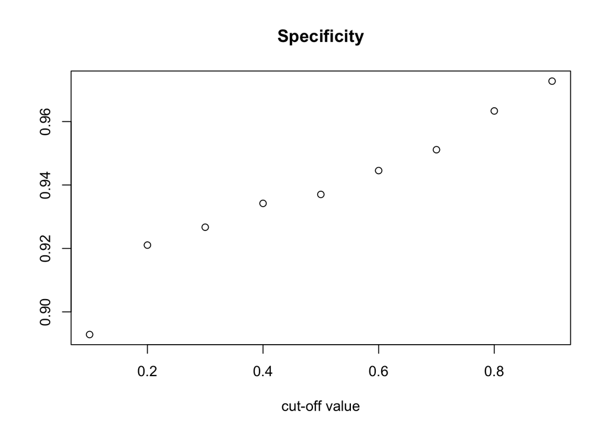

```r
plot_metric(resp=Y, pred=X, metric = "Specificity")
```

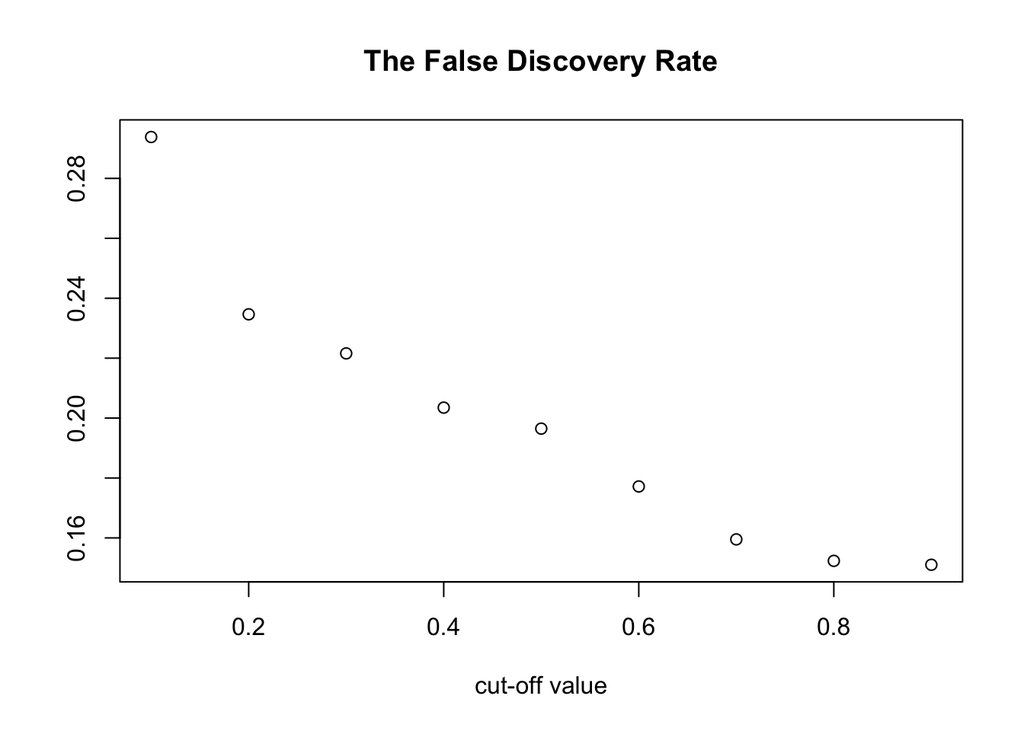

```r
plot_metric(resp=Y, pred=X, metric = "The False Discovery Rate")
```

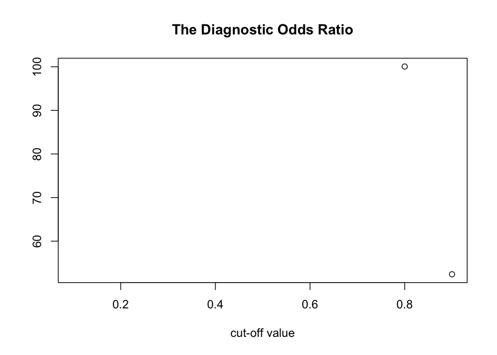

```r
plot_metric(resp=Y, pred=X, metric = "The Diagnostic Odds Ratio")
```